# Who survived the Titanic disaster? Exploring data with Multinomial Logistic Regression

Prepared by: Divij Pherwani (430990) Andrea Furmanek (345183)

04/06/2021

# Abstract

Below paper was prepared for the needs of the final project for Advanced Econometrics at the University of Warsaw. By using `Multinomial Logit Model` on the data of Titanic survivors we wanted to verify whether the socio-economic status or paying higher fare impacted passenger’s probability of survival. The data is originally available on the `Kaggle` competition website “Titanic: Machine Learning from Disaster” and contains data for 1.309 passengers indicating whether they survive, what was their material status, what gender they were, what age they were etc. As our explanatory variables are individual specific (they do not change across alternatives) we decided to use `Multinomial Logit Model`. In this paper, dependent variable `Survival` was explained with different independent variables that were selected using multinomial logit model and verified by statistical tests. The econometric model was built in `R` with the use of `mlogit, survival, stargazer packages`. The end result is a final model with significant variables that best explains survival rate.

**Keywords:** Titanic, Survival Rate, Multinomial Logit Model, Kaggle Titanic Dataset, Data pre-processing.

# 1. Introduction

The sinking of the Titanic is one of the most infamous shipwrecks in history. On April 15, 1912, during her maiden voyage, the widely considered “unsinkable” RMS Titanic sank after colliding with an iceberg. Unfortunately, there were not enough lifeboats for everyone onboard,resulting in the death of 1502 out of 2224 passengers and crew. While there was some element of luck involved in surviving, it seems some groups of people were more likely to survive than others. Therefore this topic seems interesting for further investigation to see which variables influenced survival rate the most.

We will verify the following hypothesis using `multinomial logit model`:

**Hypothesis 1:**

H0: Having a seat in higher class significantly increases the chance of passenger to survive.

H1: Having a seat in higher class did not increases the chance of passenger to survive.

**Hypothesis 2:**

H0: Paying a higher fare/having a family member on board increases the chance of passenger to survive.

H1: Paying a higher fare/having a family member on board does not increase the chance of passenger survival.

# 2. Literature review

# 3.Dataset and preprocessing

## 3.1.Dataset

The Titanic passenger data consists of a `training set`, a `test set` and a `gender_submission set` all are `.csv` files. The training set includes the response variable `Survived` and 11 other descriptive variables pertaining to 891 passengers. The test set does not include the response variable, but does contain the 11 other variables for 418 passengers. Additionally, gender submission includes only response variables for test set, that’s why we started our data preprocessing by merging them.

From a sample of the RMS Titanic data, we can see the various features present for each passenger on the ship:  
**“Survived”**: Outcome of survival (0 = No; 1 = Yes)  
**“Pclass”**: Socio-economic class (1 = Upper class; 2 = Middle class; 3 = Lower class)  
**“Name”**: Name of passenger  
**“Sex”**: Sex of the passenger  
**“Age”**: Age of the passenger (Some entries contain NaN)  
**“SibSp”**: Number of siblings and spouses of the passenger aboard  
**“Parch”**: Number of parents and children of the passenger aboard  
**“Ticket”**: Ticket number of the passenger  
**“Fare”**: Fare paid by the passenger  
**“Cabin”**: Cabin number of the passenger (Some entries contain NaN)  
**“Embarked”**: Port of embarkation of the passenger (C = Cherbourg; Q = Queenstown; S = Southampton)

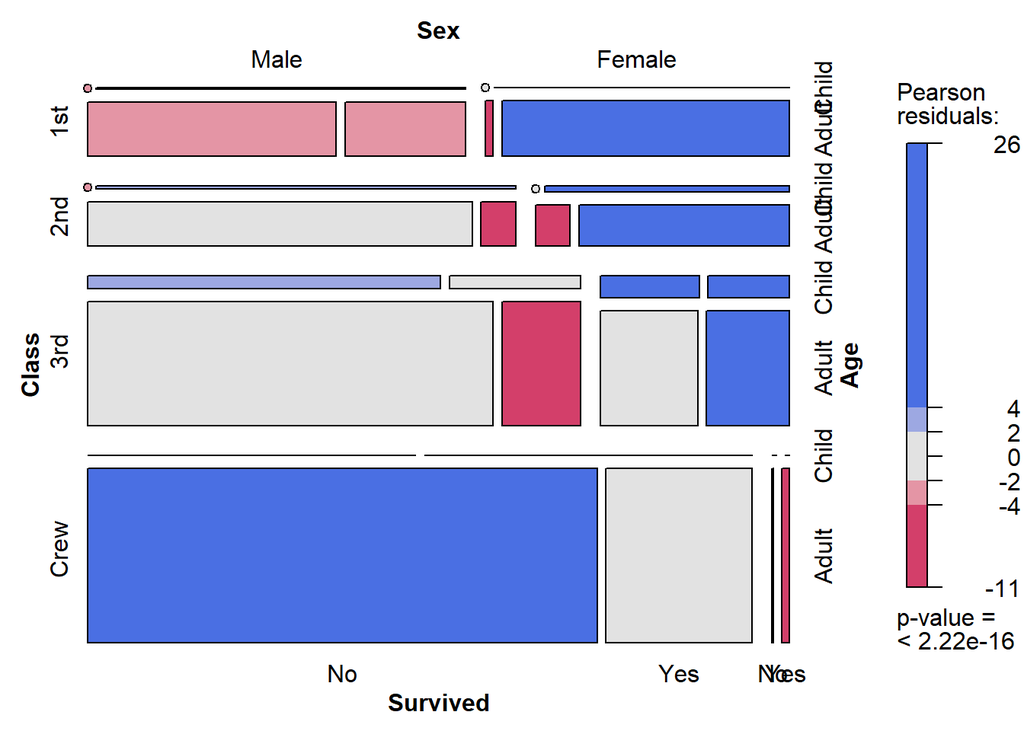

## 3.2.Preprocessing

As previously mentioned we started our data preprocessing with merging respectively datasets to get complete data for further transformations.

|  | PassengerId | Survived | Pclass | Name | Sex | Age | SibSp | Parch | Ticket | Fare | Cabin | Embarked |
| --- | --- | --- | --- | --- | --- | --- | --- | --- | --- | --- | --- | --- |
| 1 | 1 | 0 | 3 | Braund, Mr. Owen Harris | male | 22 | 1 | 0 | A/5 21171 | 7.2500 |  | S |
| 2 | 2 | 1 | 1 | Cumings, Mrs. John Bradley (Florence Briggs Thayer) | female | 38 | 1 | 0 | PC 17599 | 71.2833 | C85 | C |
| 3 | 3 | 1 | 3 | Heikkinen, Miss. Laina | female | 26 | 0 | 0 | STON/O2. 3101282 | 7.9250 |  | S |
| 4 | 4 | 1 | 1 | Futrelle, Mrs. Jacques Heath (Lily May Peel) | female | 35 | 1 | 0 | 113803 | 53.1000 | C123 | S |
| 5 | 5 | 0 | 3 | Allen, Mr. William Henry | male | 35 | 0 | 0 | 373450 | 8.0500 |  | S |
| 6 | 6 | 0 | 3 | Moran, Mr. James | male | NA | 0 | 0 | 330877 | 8.4583 |  | Q |

```
##   PassengerId      Survived          Pclass          Name
##  Min.   :   1   Min.   :0.0000   Min.   :1.000   Length:1309
##  1st Qu.: 328   1st Qu.:0.0000   1st Qu.:2.000   Class :character
##  Median : 655   Median :0.0000   Median :3.000   Mode  :character
##  Mean   : 655   Mean   :0.3774   Mean   :2.295
##  3rd Qu.: 982   3rd Qu.:1.0000   3rd Qu.:3.000
##  Max.   :1309   Max.   :1.0000   Max.   :3.000
##
##      Sex                 Age            SibSp            Parch
##  Length:1309        Min.   : 0.17   Min.   :0.0000   Min.   :0.000
##  Class :character   1st Qu.:21.00   1st Qu.:0.0000   1st Qu.:0.000
##  Mode  :character   Median :28.00   Median :0.0000   Median :0.000
##                     Mean   :29.88   Mean   :0.4989   Mean   :0.385
##                     3rd Qu.:39.00   3rd Qu.:1.0000   3rd Qu.:0.000
##                     Max.   :80.00   Max.   :8.0000   Max.   :9.000
##                     NA's   :263
##     Ticket               Fare            Cabin             Embarked
##  Length:1309        Min.   :  0.000   Length:1309        Length:1309
##  Class :character   1st Qu.:  7.896   Class :character   Class :character
##  Mode  :character   Median : 14.454   Mode  :character   Mode  :character
##                     Mean   : 33.295
##                     3rd Qu.: 31.275
##                     Max.   :512.329
##                     NA's   :1
```

Our second hypothesis has to verify whether having a family on board has increased the chance of passenger to survive, therefore a new variable `Family` has been created as a sum of already existing variables `SibSp` - number of siblings and spouses of the passenger aboard and `Parch`- number of parents and children of the passenger aboard.

|  | PassengerId | Survived | Pclass | Name | Sex | Age | SibSp | Parch | Ticket | Fare | Cabin | Embarked | Family |
| --- | --- | --- | --- | --- | --- | --- | --- | --- | --- | --- | --- | --- | --- |
| 1 | 1 | No | 3 | Braund, Mr. Owen Harris | male | 22 | 1 | 0 | A/5 21171 | 7.2500 |  | S | 1 |
| 2 | 2 | Yes | 1 | Cumings, Mrs. John Bradley (Florence Briggs Thayer) | female | 38 | 1 | 0 | PC 17599 | 71.2833 | C85 | C | 1 |
| 3 | 3 | Yes | 3 | Heikkinen, Miss. Laina | female | 26 | 0 | 0 | STON/O2. 3101282 | 7.9250 |  | S | 0 |
| 4 | 4 | Yes | 1 | Futrelle, Mrs. Jacques Heath (Lily May Peel) | female | 35 | 1 | 0 | 113803 | 53.1000 | C123 | S | 1 |
| 5 | 5 | No | 3 | Allen, Mr. William Henry | male | 35 | 0 | 0 | 373450 | 8.0500 |  | S | 0 |
| 7 | 7 | No | 1 | McCarthy, Mr. Timothy J | male | 54 | 0 | 0 | 17463 | 51.8625 | E46 | S | 0 |

# 4. Application of Econometric Models

# Exploring and Test Multinom Models

Generating 4 models using multinom function.

Formulas for models,

Performing statistical significance

```
##
## ===============================================================================================
## (Intercept) Sexmale Pclass2 Pclass3 SibSp  Parch Family EmbarkedQ EmbarkedS Fare   Age   Farepp
## -----------------------------------------------------------------------------------------------
## 9.180       -17.459 -3.826  -6.720  -1.797 0.357 -2.499  -0.554    -0.711   0.209 -4.809 0.271
## -----------------------------------------------------------------------------------------------
##
## ==================================================================================
## (Intercept) Sexmale Pclass2 Pclass3 SibSp  Parch Family EmbarkedQ EmbarkedS  Age
## ----------------------------------------------------------------------------------
## 10.603      -17.535 -4.497  -8.092  -1.831 0.431 -2.936  -0.623    -0.878   -4.859
## ----------------------------------------------------------------------------------
##
## ==============================================================
## (Intercept) Sexmale Pclass2 Pclass3 SibSp  Parch Family  Age
## --------------------------------------------------------------
## 10.747      -17.700 -5.084  -8.879  -1.888 0.475 -2.978 -4.964
## --------------------------------------------------------------
##
## =================================================
## (Intercept) Sexmale Pclass2 Pclass3 Family  Age
## -------------------------------------------------
## 10.718      -17.817 -5.045  -8.845  -2.934 -4.870
## -------------------------------------------------
```

Performing 2-tailed z test

```
##
## ===============================================================================================
## (Intercept) Sexmale Pclass2 Pclass3 SibSp Parch Family EmbarkedQ EmbarkedS Fare    Age   Farepp
## -----------------------------------------------------------------------------------------------
## 0              0    0.0001     0    0.072 0.721 0.012    0.580     0.477   0.834 0.00000 0.786
## -----------------------------------------------------------------------------------------------
##
## ==================================================================================
## (Intercept) Sexmale Pclass2 Pclass3 SibSp Parch Family EmbarkedQ EmbarkedS   Age
## ----------------------------------------------------------------------------------
## 0              0    0.00001    0    0.067 0.667 0.003    0.533     0.380   0.00000
## ----------------------------------------------------------------------------------
##
## ==============================================================
## (Intercept) Sexmale Pclass2 Pclass3 SibSp Parch Family   Age
## --------------------------------------------------------------
## 0              0    0.00000    0    0.059 0.635 0.003  0.00000
## --------------------------------------------------------------
##
## ==================================================
## (Intercept) Sexmale Pclass2 Pclass3 Family   Age
## --------------------------------------------------
## 0              0    0.00000    0    0.003  0.00000
## --------------------------------------------------
```

```
##
## =========================================================
##                             Dependent variable:
##                   ---------------------------------------
##                                  Survived
##                      (1)       (2)       (3)       (4)
## ---------------------------------------------------------
## Sexmale           -3.686*** -3.693*** -3.691*** -3.703***
##                    (0.211)   (0.211)   (0.209)   (0.208)
##
## Pclass2           -1.150*** -1.241*** -1.322*** -1.306***
##                    (0.301)   (0.276)   (0.260)   (0.259)
##
## Pclass3           -2.089*** -2.202*** -2.285*** -2.271***
##                    (0.311)   (0.272)   (0.257)   (0.257)
##
## SibSp              -0.172*   -0.175*   -0.179*
##                    (0.095)   (0.095)   (0.095)
##
## Parch               0.034     0.040     0.044
##                    (0.095)   (0.092)   (0.092)
##
## Family            -0.138**  -0.135*** -0.135*** -0.199***
##                    (0.055)   (0.046)   (0.045)   (0.068)
##
## EmbarkedQ          -0.275    -0.308
##                    (0.496)   (0.494)
##
## EmbarkedS          -0.175    -0.212
##                    (0.247)   (0.242)
##
## Fare                0.001
##                    (0.004)
##
## Age               -0.036*** -0.036*** -0.037*** -0.036***
##                    (0.007)   (0.007)   (0.007)   (0.007)
##
## Farepp              0.001
##                    (0.005)
##
## Constant          4.371***  4.544***  4.447***  4.411***
##                    (0.476)   (0.429)   (0.414)   (0.412)
##
## ---------------------------------------------------------
## Akaike Inf. Crit.  805.936   802.620   799.471   798.991
## =========================================================
## Note:                         *p<0.1; **p<0.05; ***p<0.01
```

# Exploring MLogit Data and Model

Generating data in mlogit.data format

```
## ~~~~~~~
##  first 10 observations out of 2086
## ~~~~~~~
##       Sex Pclass SibSp Parch Family Embarked Survived    Fare Age   Farepp chid
## 1    male      3     1     0      1        S     TRUE  7.2500  22  3.62500    1
## 2    male      3     1     0      1        S    FALSE  7.2500  22  3.62500    1
## 3  female      1     1     0      1        C    FALSE 71.2833  38 35.64165    2
## 4  female      1     1     0      1        C     TRUE 71.2833  38 35.64165    2
## 5  female      3     0     0      0        S    FALSE  7.9250  26  7.92500    3
## 6  female      3     0     0      0        S     TRUE  7.9250  26  7.92500    3
## 7  female      1     1     0      1        S    FALSE 53.1000  35 26.55000    4
## 8  female      1     1     0      1        S     TRUE 53.1000  35 26.55000    4
## 9    male      3     0     0      0        S     TRUE  8.0500  35  8.05000    5
## 10   male      3     0     0      0        S    FALSE  8.0500  35  8.05000    5
##    alt   idx
```

[output cut: 24 more lines]

Running the model on mlogit data

```
##
## Call:
## mlogit(formula = Survived ~ 0 | Sex + Family + Pclass + Age,     data = mldf, method = "nr")
##
## Coefficients:
## (Intercept):Yes      Sexmale:Yes       Family:Yes      Pclass2:Yes
##        4.411308        -3.703381        -0.199020        -1.306308
##     Pclass3:Yes          Age:Yes
##       -2.271218        -0.035976
```

Summary of the mlogit model

```
##
## Call:
## mlogit(formula = Survived ~ 0 | Sex + Family + Pclass + Age,
##     data = mldf, method = "nr")
##
## Frequencies of alternatives:choice
##      No     Yes
## 0.60211 0.39789
##
## nr method
## 6 iterations, 0h:0m:0s
## g'(-H)^-1g = 1.91E-06
## successive function values within tolerance limits
##
## Coefficients :
##                   Estimate Std. Error  z-value  Pr(>|z|)
## (Intercept):Yes  4.4113075  0.4115900  10.7177 < 2.2e-16 ***
## Sexmale:Yes     -3.7033811  0.2078565 -17.8170 < 2.2e-16 ***
## Family:Yes      -0.1990198  0.0678444  -2.9335  0.003352 **
## Pclass2:Yes     -1.3063077  0.2589408  -5.0448  4.54e-07 ***
## Pclass3:Yes     -2.2712179  0.2567849  -8.8448 < 2.2e-16 ***
## Age:Yes         -0.0359755  0.0073881  -4.8694  1.12e-06 ***
## ---
## Signif. codes:  0 '***' 0.001 '**' 0.01 '*' 0.05 '.' 0.1 ' ' 1
##
## Log-Likelihood: -393.5
## McFadden R^2:  0.4387
## Likelihood ratio test : chisq = 615.11 (p.value = < 2.22e-16)
```

# 5. Results & Findings

## Part A

p-value = 2.2 e-16 and LR test = 615.11

Null hypothesis: Pclass = 0, Sex = 0, Family = 0 and Age = 0

The p-value is lower than the significance level of 0.05. Therefore, we have to reject the null hypothesis which states parameters are jointly insignificant. **The parameters are jointly significant.**

|  | #Df | LogLik | Df | Chisq | Pr(>Chisq) |
| --- | --- | --- | --- | --- | --- |
| 1 | 6 | -393.4956 | NA | NA | NA |
| 2 | 1 | -701.0495 | -5 | 615.1077 | 1.100082e-130 |

## Part B

The model is created with non linear relation (square of Fare) and interactions between Age:Pclass & Sex:Pclass. The Fare and Fare^2 both have a p-value < 0.05. Similarly, for Pclass2:Age, Sexmale:Pclass2 and Sexmale:Pclass3 have p-value < 0.05. This means, we reject the null hypothesis. The parameters add meaningful addition to model. Pclass:Age interaction is insignificant.

```
##
## =============================================
##                       Dependent variable:
##                   ---------------------------
##                            Survived
## ---------------------------------------------
## Fare                       -0.015***
##                             (0.004)
##
## Fare2                     0.00004***
##                            (0.00001)
##
## Sexmale                    -5.104***
##                            (0.0001)
##
## Pclass2                    0.357***
##                            (0.0003)
##
## Pclass3                    -4.525***
##                            (0.0003)
##
## Age                        -0.029***
##                             (0.006)
##
## Pclass2:Age                -0.064***
##                             (0.009)
##
## Pclass3:Age                  0.003
##                             (0.007)
##
## Sexmale:Pclass2            -0.799***
##                            (0.0002)
##
## Sexmale:Pclass3            2.453***
##                            (0.0001)
##
## Constant                   5.900***
##                            (0.0002)
##
## ---------------------------------------------
## Akaike Inf. Crit.           768.265
## =============================================
## Note:             *p<0.1; **p<0.05; ***p<0.01
```

## Part C

Marginal effects are used to quantify the incremental risk associated with each factor.We start by creating a vector z which contains average characterstics.

The effect of Fare on Survival for each increment is by 0.3%. More the fare, more chances of survival.

```
##
## ============
## No      Yes
## ------------
## -0.003 0.003
## ------------
```

The effect of Family size on Survival for each increment in Family members is by -0.7%. More the family, lesser the chances of survival.

```
##
## ============
## No     Yes
## ------------
## 0.007 -0.007
## ------------
```

The effect of Age on Survival for each increment in Age is by -0.4%. Older the person, lesser the chances of survival.

```
##
## ============
## No     Yes
## ------------
## 0.004 -0.004
## ------------
```

## Part D

The final model is (3) in the table which can be represented by the formula:

log(P(Survived=Yes)/P(Survived=No)) = 4.411 + (-3.703 * Sexmale) + (-1.306 * Pclass2) + (-2.271 * Pclass3) + (-0.199 * Family) + (-0.036 * Age)

```
##
## ===============================================
##                        Dependent variable:
##                   -----------------------------
##                             Survived
##                      (1)       (2)       (3)
## -----------------------------------------------
## Sexmale           -3.686*** -4.927*** -3.703***
##                    (0.211)   (0.622)   (0.208)
##
## Pclass2           -1.150***  -1.382*  -1.306***
##                    (0.301)   (0.731)   (0.259)
##
## Pclass3           -2.089*** -3.834*** -2.271***
##                    (0.311)   (0.635)   (0.257)
##
## SibSp              -0.172*
##                    (0.095)
##
## Parch               0.034
##                    (0.095)
##
## Family            -0.138**  -0.189*** -0.199***
##                    (0.055)   (0.067)   (0.068)
##
## EmbarkedQ          -0.275
##                    (0.496)
##
## EmbarkedS          -0.175
##                    (0.247)
##
## Fare                0.001
##                    (0.004)
##
## Age               -0.036*** -0.040*** -0.036***
##                    (0.007)   (0.008)   (0.007)
##
## Farepp              0.001
##                    (0.005)
##
## Sexmale:Pclass2              -0.322
##                              (0.798)
##
## Sexmale:Pclass3             2.166***
##                              (0.667)
##
## Constant          4.371***  5.606***  4.411***
##                    (0.476)   (0.703)   (0.412)
##
## -----------------------------------------------
## Akaike Inf. Crit.  805.936   772.551   798.991
## ===============================================
## Note:               *p<0.1; **p<0.05; ***p<0.01
```

## Part E

The linktest is used to check the appropriate form of the model. The motivation behind the link test is the idea that if a regression is specified appropriately you should not be able to find additional independent variables.

The condition for linktest is to have yhat as significant and yhat^2 as insgnificant. (Ho: The model has appropriate form)

In the below model, we have yhat as significant and yhat2 as insignificant. Therefore, we fail to reject the null hypothesis. The model has an an appropriate form.

```
## Call:
## multinom(formula = y ~ yhat + yhat2)
##
## Coefficients:
##                  Values  Std. Err.
## (Intercept)  0.06860774 0.13547628
## yhat         1.00262896 0.05820039
## yhat2       -0.02252481 0.02900746
##
## Residual Deviance: 755.9654
## AIC: 761.9654
```

```
##
## =============================================
##                       Dependent variable:
##                   ---------------------------
##                                y
## ---------------------------------------------
## yhat                       1.003***
##                             (0.058)
##
## yhat2                       -0.023
##                             (0.029)
##
## Constant                     0.069
##                             (0.135)
##
## ---------------------------------------------
## Akaike Inf. Crit.           761.965
## =============================================
## Note:             *p<0.1; **p<0.05; ***p<0.01
```

## Hypothesis Testing

**Hypothesis 1**

H0: Having a seat in higher class insignificant to survive.

H1: Having a seat in higher class is significant to survive.

**Result 1**

The parameters Pclass2 and Pclass3 are significant as their p-value is < 0.05. Having a seat in class 2 and class 3 is significant to survival but as the coefficient is negative it decreases the probability of survival.The rate of survival is class 2 is more than in class 3. The rate of survival in class 1 is the most as pclass 2 = 0 and pclass 3 = 0.

Therefore, we reject the null hypothesis. Having a seat in higher class indeed increases the chance of passenger to survive.

**Hypothesis 2**

H0: Paying a higher fare/having a family member on board is insignificant to survive.

H1: Paying a higher fare/having a family member on board is significant survival.

**Result 2**

Fare is insignificant as the p-value is greater than 0.05. We fail to reject the null hypothesis. Paying a higher fare is insignificant to survival.

However, having a family member on board is significant as the p-value is less than 0.05. We reject the null hypothesis. Having a family member on board is significant for survival. As the coefficient is negative, it is in fact reducing the probability to survive significantly.

```
##
## =============================================
##                       Dependent variable:
##                   ---------------------------
##                            Survived
## ---------------------------------------------
## Pclass2                    -1.173***
##                             (0.290)
##
## Pclass3                    -2.109***
##                             (0.302)
##
## Age                        -0.036***
##                             (0.007)
##
## Sexmale                    -3.697***
##                             (0.208)
##
## Family                     -0.219***
##                             (0.071)
##
## Fare                         0.002
##                             (0.002)
##
## Constant                   4.232***
##                             (0.447)
##
## ---------------------------------------------
## Akaike Inf. Crit.           799.931
## =============================================
## Note:             *p<0.1; **p<0.05; ***p<0.01
```

# Conclusions

In our analysis, we concluded that an econometric model can be useful in predicting what features increases survival rate during sinking of the Titanic in 1912. As we know from literature one of the reasons that the shipwreck lead to such loss of life is that were not enough lifeboats for the passengers and crew. Although there was some element of luck involved in surviving the sinking, some groups of people were more likely to survive than others, like younger passengers, the upper-class and those who had no family members on board which we confirmed with the results of the Multinomial Logit Model.

# Bibliography

1. Whitley M., “Using statistical learning to predict survival of passengers on the RMS Titanic” K-State Research Exchange, (1), 2015, pp. 32
2. Kshirsagar V., Phalke N., “Titanic Survival Analysis using Logistic Regression” International Research Journal of Engineering and Technology (IRJET), (2), 2019, pp. 90︎
3. Donges N., “Predicting the Survival of Titanic Passengers” towardsdatascience.com, (3), 2018︎

# Appendix

```r
knitr::opts_chunk$set(echo = FALSE,message = FALSE,warning = FALSE)
# Loading Libraries
library("vcd")
library("sandwich")
library("zoo")
library("lmtest")
library("MASS")
library("aod")
library("nnet")
library("Formula")
library("miscTools")
library("maxLik")
library("mlogit")
library("car")
library("survival")
library("AER")
library("stargazer")
mosaic(~Class+Sex+Age+Survived, data=Titanic, shade=TRUE, legend=TRUE)
# Loading Dataset
setwd(dirname(rstudioapi::getSourceEditorContext()$path))
dfx <- read.csv("train.csv")
df1 <- read.csv("test.csv")
df2 <- read.csv("gender_submission.csv")
dfy <- merge(df1, df2)
df <- rbind(dfx, dfy)
head(df)
# EDA
summary(df)
# Processing & Cleaning Data set
fdf <- subset(df, df$Embarked != "")
fdf <- subset(fdf, fdf$Fare != "")
fdf <- subset(fdf, fdf$Age != "")
fdf$Family <- fdf$SibSp + fdf$Parch
fdf$Survived <- ifelse(fdf$Survived == 0, "No", "Yes")
fdf$Pclass <- as.factor(fdf$Pclass)
fdf$Embarked <- as.factor(fdf$Embarked)
fdf$Survived <- as.factor(fdf$Survived)
fdf$Sex <- as.factor(fdf$Sex)
head(fdf)
# Filtering Data
fdf <- fdf[,c("Sex", "Pclass", "SibSp", "Parch", "Family", "Embarked", "Survived", "Fare", "Age")]
fdf$Farepp <- fdf$Fare/(fdf$Family + 1)
# Modeling
model1 <- multinom(Survived ~ ., data = fdf)
model2 <- multinom(Survived ~ .-Fare - Farepp, data = fdf)
model3 <- multinom(Survived ~ .-Fare - Farepp-Embarked, fdf)
model4 <- multinom(Survived ~ .-Fare - Farepp-Embarked-SibSp-Parch, fdf)
#summary(model1); summary(model2); summary(model3); summary(model4)
# statistical significance
z1 <- summary(model1)$coefficients/summary(model1)$standard.errors
z2 <- summary(model2)$coefficients/summary(model2)$standard.errors
z3 <- summary(model3)$coefficients/summary(model3)$standard.errors
z4 <- summary(model4)$coefficients/summary(model4)$standard.errors
stargazer(z1,z2,z3,z4, type = "text")
# 2-tailed z test
p1 <- (1 - pnorm(abs(z1), 0, 1)) * 2
p2 <- (1 - pnorm(abs(z2), 0, 1)) * 2
p3 <- (1 - pnorm(abs(z3), 0, 1)) * 2
p4 <- (1 - pnorm(abs(z4), 0, 1)) * 2
stargazer(p1,p2,p3,p4, type = "text")
# Comparing all Models
stargazer(model1, model2, model3, model4, type = "text")
# Generating data in mlogit.data format
mldf <- mlogit.data(fdf, shape = "wide", choice= "Survived")
head(mldf)
# Running the model on mlogit data
model <- mlogit(Survived~ 0| Sex + Family + Pclass + Age, data = mldf)
model
# Summary of the mlogit model
summary(model)
# General-to-specific method for variables selection
x <- multinom(Survived~ Pclass + Sex + Family + Age, data = fdf)
y <- multinom(Survived~1, data=fdf)
lrtest(x, y)
# One nonlinear relationship and interaction between variables

fdf$Fare2 <- fdf$Fare^2
fdf$Farepp2 <- fdf$Farepp^2
nlr_model <- multinom(Survived ~ Fare + Fare2 + Sex + Pclass + Age+ Age*Pclass
                      + Sex * Pclass, data = fdf)
stargazer(nlr_model, type = "text")

# Calculation and interpretation of marginal effects for the model

model <- mlogit(Survived~ 0| Fare + Family +Age, data = mldf)
z <- with(mldf, data.frame(Fare = tapply(Fare, index(model)$alt, mean), Family =
                             tapply(Family, index(model)$alt, mean),
                           Age = tapply(Age, index(model)$alt, mean)))

# Marginal effects for Fare
x <- effects(model, covariate = "Fare", data = z)
stargazer(x, type = "text")
# Marginal effects for Family
y <- effects(model, covariate = "Family", data = z)
stargazer(y, type = "text")

# Marginal effects for Age
z <- effects(model, covariate = "Age", data = z)
stargazer(z, type = "text")
#present models in one quality table

final <- multinom(Survived~ Sex + Family + Pclass + Age + Pclass*Sex, data = fdf)

stargazer(model1, final, model4, type="text")

# perform the linktest and interpret the result

linktest = function(model)
{
  y = as.numeric(fdf$Survived) -1
  yhat = log(model$fitted.values/(1-model$fitted.values))
  yhat2 = yhat^2
  # auxiliary regression
  aux.reg = multinom(y~yhat+yhat2)
  show(summary(aux.reg))
  return(aux.reg)
}

mylogit <- multinom(Survived~ Sex + Pclass + Age + Family + Sex*Pclass, data=fdf)
lt <- linktest(mylogit)
stargazer(lt, type="text")
# Hypothesis Testing
hypothesis <- multinom(Survived ~ Pclass + Age + Sex + Family + Fare, data = fdf)
stargazer(hypothesis, type = "text")
```